# The Solar Neighborhood

The Solar Neighborhood can be roughly defined as all of the objects within 10 pc of the Sun.

- Objects within 10 pc of the Sun will have parallax values greater than 100 mas.

Create and run a Gaia query to find a high quality complete sample of all of the objects Gaia surveyed within the Solar Neighborhood.

- Your sample should only have high quality data (parallax SNR > 15)
- All of your objects should have bp-rp colors and radial velocity measurements.

You will want the columns: `source_id, bp_rp, parallax, parallax_over_error, pmra, pmdec, radial_velocity`

Don't print out the entire object table!

```python
import matplotlib.pyplot as plt
import matplotlib.image as mpimg

import numpy as np
import astropy.units as u

from astroquery.simbad import Simbad

from astropy.table import QTable
from astroquery.gaia import Gaia
```

```python
my_query = f"""
SELECT TOP 500
source_id, bp_rp, parallax, parallax_over_error, pmra, pmdec, radial_velocity
FROM gaiadr3.gaia_source_lite
WHERE parallax > 100
AND bp_rp IS NOT NULL
AND radial_velocity IS NOT NULL
ORDER BY parallax DESC
"""
```

```python
my_job_query = Gaia.launch_job_async(my_query)
```

```
INFO: Query finished. [astroquery.utils.tap.core]
```

```python
print(my_job_query)
```

```
<Table length=216>
        name         dtype    unit                              description
------------------- ------- -------- ------------------------------------------------------------------
          source_id   int64          Unique source identifier (unique within a particular Data Release)
              bp_rp float32      mag                                                     BP - RP colour
           parallax float64      mas                                                           Parallax
parallax_over_error float32                                      Parallax divided by its standard error
               pmra float64 mas / yr                         Proper motion in right ascension direction
              pmdec float64 mas / yr                             Proper motion in declination direction
    radial_velocity float32   km / s                                                    Radial velocity
Jobid: 787a7b23-0824-11f1-a559-bc97e148b76b-O
Phase: COMPLETED
Owner: None
Output file: async_20260212150655.vot
Results: None
```

```python
my_table = my_job_query.get_results()
my_table[0:5]
```

*Table length=5*

| source_id int64 | bp_rp mag float32 | parallax mas float64 | parallax_over_error float32 | pmra mas / yr float64 | pmdec mas / yr float64 | radial_velocity km / s float32 |
| --- | --- | --- | --- | --- | --- | --- |
| 5853498713190525696 | 3.8045802 | 768.0665391873573 | 15400.477 | -3781.741008265163 | 769.4650146478623 | -21.942726 |
| 4472832130942575872 | 2.8336968 | 546.975939730948 | 13634.737 | -801.5509783684709 | 10362.394206546573 | -110.46822 |
| 762815470562110464 | 2.2156086 | 392.75294543876464 | 12248.019 | -580.0570872139048 | -4776.588719443488 | -85.11064 |
| 5140693571158946048 | 3.8285542 | 373.8443122683992 | 746.38806 | 3178.6942575748953 | 584.0613350385156 | 10.249533 |
| 5140693571158739840 | 3.7529564 | 367.71189618147696 | 495.70142 | 3385.315810465071 | 544.3863845619521 | 21.458223 |

## Make a plot of `pmra` vs `pmdec` for the objects in the Solar Neighborhood

- Adjust your values for the X and Y limits so the center of the plot is (0,0)
- Make the points easy to see
- Label the axes

```python
np.max(my_table['pmdec']), np.min(my_table['pmdec'])
```

```
(np.float64(10362.394206546573), np.float64(-5817.8001940492695))
```

```python
np.max(my_table['pmra']), np.min(my_table['pmra'])
```

```
(np.float64(6765.995136250774), np.float64(-4406.469178827325))
```

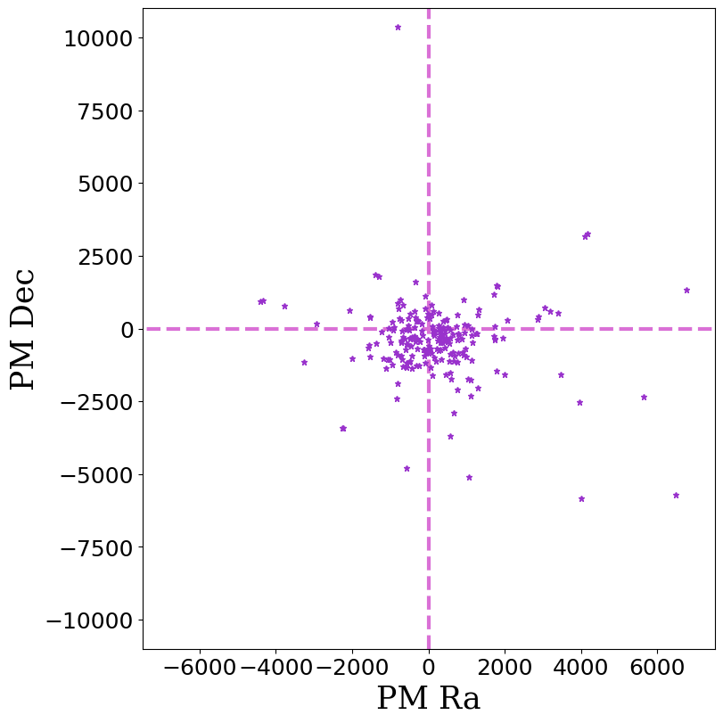

```python
fig, ax = plt.subplots(
    figsize = (8, 8),
    constrained_layout = True
)

ax.set_ylim(-11000,11000)
ax.set_xlim(-7500,7500)

ax.tick_params(axis='both', which='major', labelsize = 18)

###

ax.set_xlabel("PM Ra",
              fontfamily = 'serif',
              fontsize = 25)

ax.set_ylabel("PM Dec",
              fontfamily = 'serif',
              fontsize = 25)


ax.vlines(0, -11000, 11000,
          color = 'Orchid',
          linewidth = 3,
          linestyle = '--')

ax.hlines(0, -11000, 11000,
          color = 'Orchid',
          linewidth = 3,
          linestyle = '--')

ax.plot(my_table['pmra'], my_table['pmdec'],
        color = "DarkOrchid",
        marker = "*",
        linestyle = "None",
        markersize = 5
       );
```

## Make a histogram of the values of the `radial velocity`.

- Use bin sizes of 10 km/s
- Label the axes

```python
np.max(my_table['radial_velocity']), np.min(my_table['radial_velocity'])
```

```
(np.float32(245.05313), np.float32(-414.01544))
```

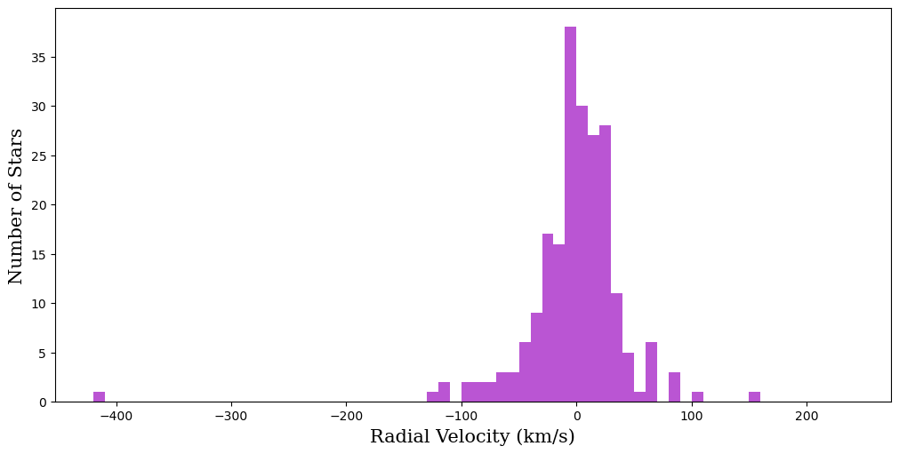

```python
my_bins = np.arange(-420,250,10)

fig, ax = plt.subplots(
    figsize = (10, 5),
    constrained_layout = True
)

ax.set_xlabel("Radial Velocity (km/s)",
              fontfamily = 'serif',
              fontsize = 15)

ax.set_ylabel("Number of Stars",
              fontfamily = 'serif',
              fontsize = 15)

ax.hist(my_table['radial_velocity'],
        bins = my_bins,
        histtype = 'stepfilled',
        facecolor = 'MediumOrchid');
```

## Calculate the total space velocity for the Solar Neighborhood objects

```python
my_table['Total_PM'] = np.sqrt(my_table['pmra'] ** 2 + my_table['pmdec'] ** 2)
```

```python
my_table['Tan_Velocity'] = 4.74047 * ( my_table['Total_PM'] / my_table['parallax'] )
```

```python
my_table['Space_Velocity'] = np.sqrt(my_table['Tan_Velocity'] ** 2 + my_table['radial_velocity'] ** 2)
```

## Make a histogram of the values of the `total space velocity`.

- Use bin sizes of 10 km/s
- Label the axes

```python
np.max(my_table['Space_Velocity']), np.min(my_table['Space_Velocity'])
```

```
(np.float64(415.8951282492758), np.float64(4.569050703620665))
```

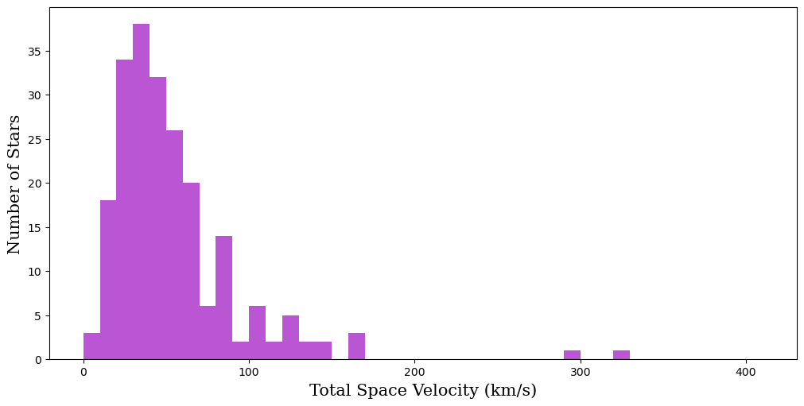

```python
my_bins2 = np.arange(0,420,10)

fig, ax = plt.subplots(
    figsize = (10, 5),
    constrained_layout = True
)

my_bins=10

ax.set_xlabel("Total Space Velocity (km/s)",
              fontfamily = 'serif',
              fontsize = 15)

ax.set_ylabel("Number of Stars",
              fontfamily = 'serif',
              fontsize = 15)

ax.hist(my_table['Space_Velocity'],
        bins = my_bins2,
        histtype = 'stepfilled',
        facecolor = 'MediumOrchid');
```

## Speedy Object

You should notice that one of the objects has a very high total space velocity.

Print out the following sentence for the high velocity object.

`The object with the highest space velocity in the solar neighborhood is OBJECT_ID with a velocity of VELOCITY km/s and a parallax of PARALLAX mas. The color of the object is BP_RP which is within BP_RP - SOLAR_COLOR mags of the Sun's color.`

- The Sun has a `bp_rp` value of 0.82
- Use `f-string` formatting to make your output look nice.
- **All floats should be printed to one decimal place**.
- Your output should **NOT** be all be all on one line that needs to be scrolled through.
- Replace the CAP values with data. **DO NOT HARDCODE!!** - use variables.

```python
idx = np.argmax(my_table['Space_Velocity'])

high_v_obj = my_table[idx]
```

```python
my_string=f"""The object with the highest space velocity in the solar neighborhood is {high_v_obj['source_id']:.1f}
with a velocity of {high_v_obj['Space_Velocity']:.1f} km/s and a parallax of {high_v_obj['parallax']:.1f} mas.
The color of the object is {high_v_obj['bp_rp']:.1f} which is within {(high_v_obj['bp_rp'] - 0.82):.1f} mags of the Sun's color."""

print(my_string)
```

```
The object with the highest space velocity in the solar neighborhood is 3320184202856435712.0
with a velocity of 415.9 km/s and a parallax of 123.2 mas.
The color of the object is 0.8 which is within 0.0 mags of the Sun's color.
```

# Pretty Pictures - Pick an Object

## Pick an interesting-to-you (non-Solar System) object.

### [Here is a good place for ideas](https://en.wikipedia.org/wiki/Lists_of_astronomical_objects)

### The [Arp catalog](https://en.wikipedia.org/wiki/Atlas_of_Peculiar_Galaxies) is a particularly good list for the more decerning tastes.

### Don't pick a field with just one bright star in it (i.e Sirius).

# [The STScI Digitized Sky Survey](https://archive.stsci.edu/cgi-bin/dss_form)

- Download a GIF images of your object
- Adjust the width and height so that you can see the entire object with a little context
- Pick the Survey that looks best to you
- Upload the GIF of your object to this directory
- Plot up the image

```python
my_field_image = mpimg.imread("./NGC2685.gif")
```

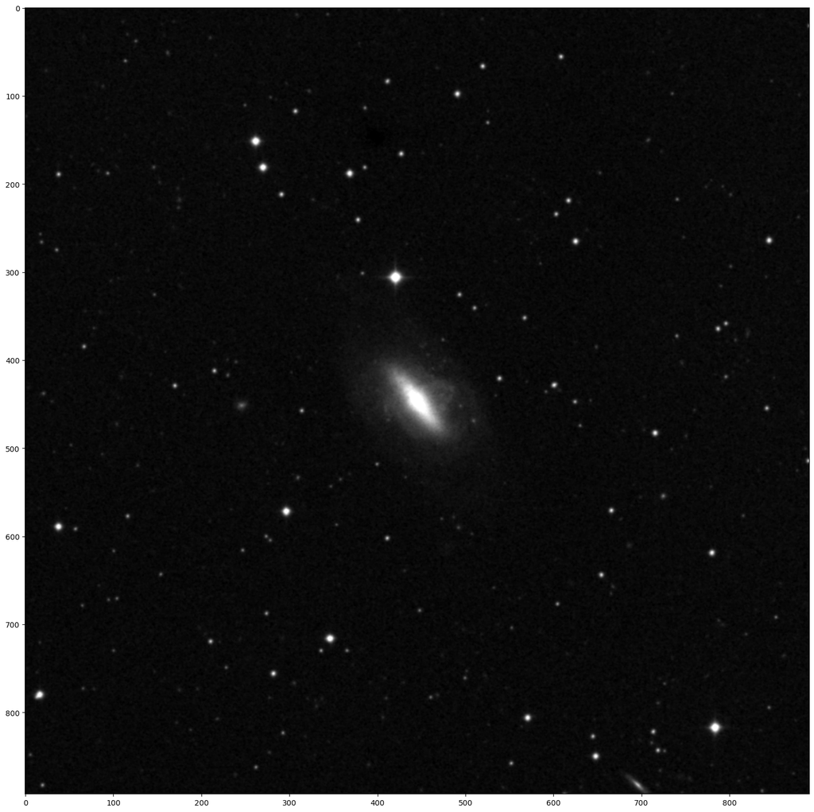

```python
fig, ax = plt.subplots(
    figsize = (15, 15),
    constrained_layout = True
)

ax.imshow(my_field_image, cmap = plt.cm.gray);
```

### Due Wed Feb 18 - 1 pm

- `File -> Download as -> HTML (.html)`
- `upload your .html file to the class Canvas page`